# YeshaDoshiAssignment2 (2)

**Introduction**

In this report, we look into analyzing how people vote on gaming legalization in different US counties, using a detailed dataset of 1287 records. This data includes key information like population, income, and how many people are for or against gaming. We've applied three main machine learning techniques—Decision Trees, Naïve Bayes, and K-Nearest Neighbors—to predict voting outcomes, ensuring our approach is solid by preprocessing data and selecting relevant variables.

Prepping the data was key, as we had to make sure everything was in the right format and only included useful information for our predictions. Our goal with this analysis is to shed light on what drives voting behavior on this issue and provide valuable insights into the mix of economic, demographic, and social factors that influence these decisions. This concise journey through data analysis to prediction showcases our methodical approach to understanding gaming legalization votes in a political data science context.

```python
# Mounting Google Drive
from google.colab import drive
drive.mount('/content/drive')
```

```python
#implort libraries
import pandas as pd
from sklearn.model_selection import train_test_split
from matplotlib import pyplot as plt
from sklearn import tree
from sklearn.tree import DecisionTreeClassifier
from sklearn.metrics import confusion_matrix
from sklearn.metrics import ConfusionMatrixDisplay
from sklearn.metrics import classification_report
from sklearn.naive_bayes import MultinomialNB
import seaborn as sns
from sklearn import preprocessing
import numpy as np
from sklearn.impute import SimpleImputer
from sklearn.tree import plot_tree
from sklearn.neighbors import KNeighborsClassifier
from sklearn.metrics import accuracy_score, precision_score, recall_score, f1_score
from sklearn.model_selection import train_test_split
from sklearn.tree import plot_tree
from sklearn.model_selection import cross_val_score
```

```python
#Read data
GamingBallotData = pd.read_csv("/content/drive/MyDrive/Gaming Ballot Data Set-1.csv")
GamingBallotData
```

|  | State No | County No | FOR | AGAINST | TOTAL CASTE | DEPENDENT VARIABLE | BALLOT TYPE | POPULATION | PCI | MEDIUM FAMILY INCOME | ... | UNEMPLOYMENT RATE | AGE LESS THAN 18 | AGE24 | AGE44 | AGE64 | AGE OLDER THAN 65 | MSA | PERCENT MINORITY | NO OF OLDER | NO OF YOUNGER |
| --- | --- | --- | --- | --- | --- | --- | --- | --- | --- | --- | --- | --- | --- | --- | --- | --- | --- | --- | --- | --- | --- |
| 0 | 1 | 1 | 42385 | 22992 | 65377 | 1 | 1 | 265038 | $15,607 | $34,618 | ... | 5.0 | 80600 | 22627 | 94724 | 46933 | 20154 | 1 | 0.25 | 67087 | 189448 |
| 1 | 1 | 2 | 2015 | 1852 | 3867 | 1 | 1 | 13617 | $13,740 | $23,114 | ... | 7.0 | 4285 | 1861 | 4092 | 2114 | 1265 | 2 | 0.40 | 3379 | 8184 |
| 2 | 1 | 3 | 51959 | 48406 | 100365 | 1 | 1 | 391511 | $24,187 | $44,874 | ... | 3.0 | 111243 | 29574 | 150740 | 70783 | 29171 | 1 | 0.15 | 99954 | 301480 |
| 3 | 1 | 4 | 957 | 856 | 1813 | 1 | 1 | 5345 | $12,816 | $27,359 | ... | 5.0 | 1647 | 229 | 1670 | 1178 | 621 | 2 | 0.26 | 1799 | 3340 |
| 4 | 1 | 5 | 942 | 1129 | 2071 | 0 | 1 | 4556 | $19,017 | $23,054 | ... | 1.0 | 1192 | 220 | 1231 | 973 | 940 | 2 | 0.07 | 1913 | 2462 |
| ... | ... | ... | ... | ... | ... | ... | ... | ... | ... | ... | ... | ... | ... | ... | ... | ... | ... | ... | ... | ... | ... |
| 1282 | 18 | 41 | 44069 | 27316 | 71385 | 1 | 1 | 354527 | $18,893 | $27,622 | ... | 15.6 | 124607 | 30781 | 100927 | 62657 | 35555 | 1 | 0.50 | 98212 | 201854 |
| 1283 | 18 | 42 | 10026 | 9755 | 19781 | 1 | 1 | 53029 | $20,082 | $33,810 | ... | 8.0 | 11972 | 3497 | 16099 | 12015 | 9446 | 2 | 0.13 | 21461 | 32198 |
| 1284 | 18 | 43 | 126397 | 76905 | 203302 | 1 | 1 | 732143 | $28,711 | $49,763 | ... | 5.6 | 208062 | 65744 | 235177 | 146412 | 76748 | 1 | 0.38 | 223160 | 470354 |
| 1285 | 18 | 44 | 26412 | 23464 | 49876 | 1 | 1 | 153293 | $25,791 | $38,751 | ... | 5.4 | 39727 | 23948 | 46570 | 27627 | 15421 | 1 | 0.35 | 43048 | 93140 |
| 1286 | 18 | 45 | 7099 | 6291 | 13390 | 1 | 1 | 59953 | $16,405 | $26,842 | ... | 13.5 | 19963 | 5315 | 16815 | 11403 | 6457 | 1 | 0.30 | 17860 | 33630 |

1287 rows × 31 columns

```python
GamingBallotData.keys()
```

```
Index(['State No', 'County No', 'FOR', 'AGAINST', 'TOTAL CASTE',
       'DEPENDENT VARIABLE', 'BALLOT TYPE', 'POPULATION', 'PCI',
       'MEDIUM FAMILY INCOME', 'SIZE OF COUNTY', 'POPULATION DENSITY',
       'PERCENT WHITE', 'PERCENT BLACK', 'PERCENT OTHER', 'PERCENT MALE',
       'PERCENT FEMALE', 'NO OF CHURCHES', 'NO OF CHURCH MEMBERS',
       'PERCENT CHURCH MEMBERS OF POPULATION', 'POVERTY LEVEL',
       'UNEMPLOYMENT RATE', 'AGE LESS THAN 18', 'AGE24', 'AGE44', 'AGE64',
       'AGE OLDER THAN 65', 'MSA', 'PERCENT MINORITY', 'NO OF OLDER',
       'NO OF YOUNGER'],
      dtype='object')
```

```python
# Examine variable type
GamingBallotData.dtypes
```

```
State No                                  int64
County No                                 int64
FOR                                       int64
AGAINST                                   int64
TOTAL CASTE                               int64
DEPENDENT VARIABLE                        int64
BALLOT TYPE                               int64
POPULATION                                int64
PCI                                      object
MEDIUM FAMILY INCOME                     object
SIZE OF COUNTY                          float64
POPULATION DENSITY                      float64
PERCENT WHITE                           float64
PERCENT BLACK                           float64
PERCENT OTHER                           float64
PERCENT MALE                            float64
PERCENT FEMALE                          float64
NO OF CHURCHES                            int64
NO OF CHURCH MEMBERS                     object
PERCENT CHURCH MEMBERS OF POPULATION     object
POVERTY LEVEL                           float64
UNEMPLOYMENT RATE                       float64
AGE LESS THAN 18                          int64
AGE24                                     int64
AGE44                                     int64
AGE64                                     int64
AGE OLDER THAN 65                         int64
MSA                                       int64
PERCENT MINORITY                        float64
NO OF OLDER                               int64
NO OF YOUNGER                             int64
dtype: object
```

```python
# Check for missing values
print(GamingBallotData.isnull().sum())
```

```
State No                                0
County No                               0
FOR                                     0
AGAINST                                 0
TOTAL CASTE                             0
DEPENDENT VARIABLE                      0
BALLOT TYPE                             0
POPULATION                              0
PCI                                     0
MEDIUM FAMILY INCOME                    0
SIZE OF COUNTY                          0
POPULATION DENSITY                      0
PERCENT WHITE                           0
PERCENT BLACK                           0
PERCENT OTHER                           0
PERCENT MALE                            0
PERCENT FEMALE                          0
NO OF CHURCHES                          0
NO OF CHURCH MEMBERS                    0
PERCENT CHURCH MEMBERS OF POPULATION    0
POVERTY LEVEL                           0
UNEMPLOYMENT RATE                       0
AGE LESS THAN 18                        0
AGE24                                   0
AGE44                                   0
AGE64                                   0
AGE OLDER THAN 65                       0
MSA                                     0
PERCENT MINORITY                        0
NO OF OLDER                             0
NO OF YOUNGER                           0
dtype: int64
```

```python
# Set missing values as none
GamingBallotData.fillna(GamingBallotData.mean(), inplace=True)
GamingBallotData = GamingBallotData.fillna('None')
```

```python
# Basic summary statistics
print(GamingBallotData.describe())
```

```
          State No    County No            FOR        AGAINST    TOTAL CASTE  \
count  1287.000000  1287.000000    1287.000000    1287.000000    1287.000000
mean     10.399378    57.271950    6460.944056    7330.511267   13791.455322
std       5.047112    54.349102   14766.945874   15099.602719   28431.805279
min       1.000000     1.000000      44.000000      15.000000      59.000000
25%       8.000000    20.000000     812.000000     908.500000    1818.000000
50%      10.000000    41.000000    1847.000000    2017.000000    3989.000000
75%      15.000000    70.000000    4669.500000    6013.500000   10767.500000
max      18.000000   251.000000  161415.000000  121925.000000  245523.000000

       DEPENDENT VARIABLE  BALLOT TYPE    POPULATION  SIZE OF COUNTY  \
count         1287.000000  1287.000000  1.287000e+03     1287.000000
mean             0.425796     1.542347  5.247528e+04     1000.487801
std              0.494655     0.498397  1.097376e+05      778.794180
min              0.000000     1.000000  3.270000e+02      120.800000
25%              0.000000     1.000000  6.541500e+03      534.250000
50%              0.000000     2.000000  1.612600e+04      832.500000
75%              1.000000     2.000000  4.313700e+04     1140.450000
max              1.000000     2.000000  1.206243e+06     6347.800000

       POPULATION DENSITY  ...  UNEMPLOYMENT RATE  AGE LESS THAN 18  \
count         1287.000000  ...        1287.000000       1287.000000
mean            81.573497  ...           6.050505      14419.316239
std            221.758540  ...           3.410285      30487.082118
min              0.300000  ...           0.600000         87.000000
25%              7.025000  ...           3.600000       1790.500000
50%             22.600000  ...           5.400000       4568.000000
75%             64.865000  ...           7.600000      12004.000000
max           3404.480000  ...          38.500000     353009.000000

               AGE24          AGE44          AGE64  AGE OLDER THAN 65  \
count    1287.000000    1287.000000    1287.000000        1287.000000
mean     5204.804973   16497.122766   10298.944833        6754.410256
std     11700.168130   37260.003718   20948.274331       13508.404172
min        16.000000     108.000000      71.000000          21.000000
25%       417.500000    1717.000000    1328.500000        1106.500000
50%      1302.000000    4520.000000    3287.000000        2401.000000
75%      4119.000000   12577.500000    8947.000000        5813.500000
max    137916.000000  437537.000000  202133.000000      122335.000000

               MSA  PERCENT MINORITY    NO OF OLDER  NO OF YOUNGER
count  1287.000000       1287.000000    1287.000000    1287.000000
mean      1.781663          0.195602   17053.355089   32994.245532
std       0.413278          0.189275   34050.346392   74520.007437
min       1.000000          0.000000      92.000000     216.000000
25%       2.000000          0.040000    2429.000000    3434.000000
50%       2.000000          0.140000    5772.000000    9040.000000
75%       2.000000          0.300000   14977.000000   25155.000000
max       2.000000          0.970000  324468.000000  875074.000000

[8 rows x 27 columns]
```

```python
# Convert 'PCI' and 'MEDIUM FAMILY INCOME' from text to numeric, removing any symbols like '$' and ','.
GamingBallotData['PCI'] = GamingBallotData['PCI'].replace('[\$,]', '', regex=True).astype(float)
GamingBallotData['MEDIUM FAMILY INCOME'] = GamingBallotData['MEDIUM FAMILY INCOME'].replace('[\$,]', '', regex=True).astype(float)
```

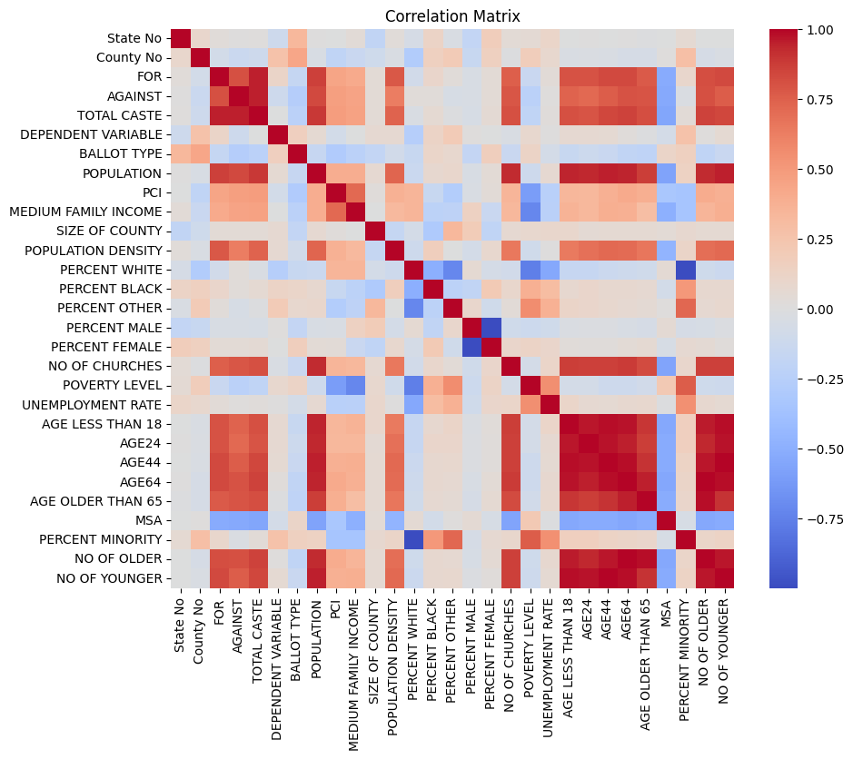

```python
# Correlation analysis
plt.figure(figsize=(10, 8))
sns.heatmap(GamingBallotData.corr(), annot=False, cmap='coolwarm')
plt.title('Correlation Matrix')
plt.show()
```

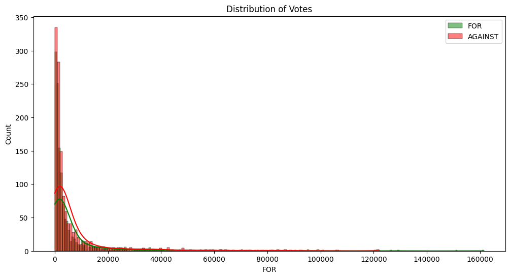

```python
# Distribution of FOR and AGAINST votes
plt.figure(figsize=(12, 6))
sns.histplot(GamingBallotData['FOR'], color='green', kde=True, label='FOR')
sns.histplot(GamingBallotData['AGAINST'], color='red', kde=True, label='AGAINST')
plt.title('Distribution of Votes')
plt.legend()
plt.show()
```

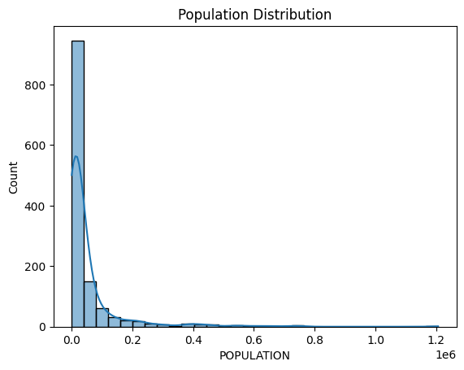

```python
# Population Distribution
sns.histplot(GamingBallotData['POPULATION'], bins=30, kde=True)
plt.title('Population Distribution')
plt.show()
```

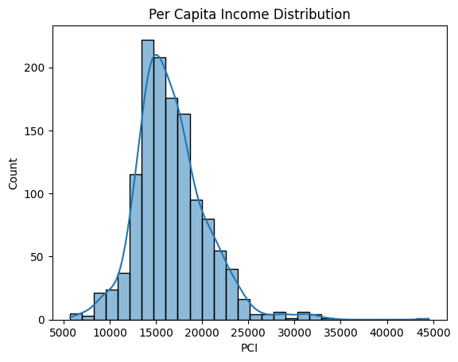

```python
# Per Capita Income Distribution
sns.histplot(GamingBallotData['PCI'], bins=30, kde=True)
plt.title('Per Capita Income Distribution')
plt.show()
```

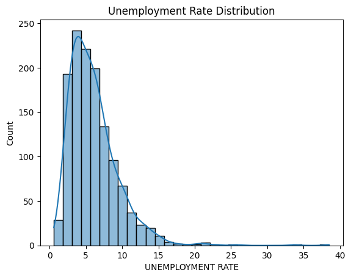

```python
# Unemployment Rate Distribution
sns.histplot(GamingBallotData['UNEMPLOYMENT RATE'], bins=30, kde=True)
plt.title('Unemployment Rate Distribution')
plt.show()
```